# Cervical Cancer Interpolation and Prediction

Antina Lee

Joey Haymaker

Maria Diaz Ortiz

Due 12/13/2017

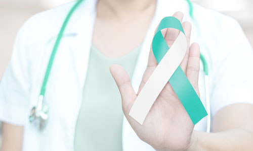

## 0.1 Summary

## 0.2 Description of the Problem

The incidence of cervical cancer in the US has decreased singnificanty over the past 40 years (from being the #1 cause of death for women in the US to being 14th in frequency), mosly due to early detection due to pap smear screening. However, it still remains a large source of morbidity and mortality both in the US and globally. In 2014, there were over 12,500 new cervical cancer diagnoses and over 4,000 cervical cancer-associated deaths in the US alone. On a global scale, cervical cancer is still the 3rd most common neoplasia and the #2 cause of cancer-related deaths among women. Cervical cancer is almost exclusively caused by the human papilloma virus (HPV), a sommon sexually transmitted disease. There are multiple subtypes of HPV, some of which are associated with warts and others which are notorious for causing cervical cancer. Although recently the US Food and Drug Administration (FDA) has approved Gardasil and Cevarix, two vaccines that protect against “high risk” types of cervical cancer, these vaccines do not protect against all types of cervical cancer. In order to further decrease the incidence of cervical cancer, it is important to understand what behavioral and demographic factors increase the risk of acquiring cervical cancer. Thus, the goal of our analysis is two-fold: 1) to identify factors that increase the risk of cervical cancer and 2) to develop a model that predicts the risk of cervical cancer.

## 0.3 Description of the Data

The dataset was obtained from kaggle () and was collected through administering questionnaires to 858 patients at ‘Hospital Universitario de Caracas’ in Caracas, Venezuela. It includes demographic information, habits, and historic medical records of the patients in question. Missing values correspond to patients who failed to answer a question due to privacy concerns. A more detailed description of each variable is outlined below:

Demographic/behavioral variables:

- `Age` (integer) - Corresponds to the age at which the patient filled the questionnaire
- `Number.of.sexual.partners` (integer) - Numer of sexual partners
- `First.sexual.intercourse` (integer) - Age at first sexual intercourse
- `Num.of.pregnancies` (integer) - Number of pregnancies
- `Smoker.status` (factor) - Categorical value that corresponds to whether someone is a non-smoker (0), light-medium smoker (1), or heavy smoker (2).
  - This variable was generated by using the following transformation to define “pack-years”: $Packyears = Smokes (yes=1, no=0) \times Smokes (years) \times Smokes (packs/year)$. Then, pack years was log transformed ($log(packyears+1)$) because, when excluding non-smokers ($log(packyears+1)=0$), the distribution for number of $log(packyears+1)$ looks more normal. We calculated the mean for this group ($mean(log(packyears+1))=2.346$) and 0-2 were assigned as follows:
    - $Non-smoker(0)$: 0 log(packyears+1)
    - $Light-Medium smoker (1)$: Between 0 and 2.346 log(packyears+1)
    - $Heavy smoker (2)$: > 2.346 log(packyears+1)
- `log.Years.HCP` (integer)** - Generated by multiplying $Years.HCP = Hormonal.Contraceptives(yes=1,no=0) \times Hormonal.Contraceptive.Years$ then taking the log transofrmation: $log.Years.HCP = log(Years.HCP + 1)$
- `log.Years.IUD` (integer)** - Generated by multiplying $Years.IUD = IUD(yes=1,no=0) \times IUD.Years$ then taking the log transofrmation: $log.Years.IUD = log(Years.IUD + 1)$

** The variables `log.Years.HCP` and `log.Years.IUC` were used instead of `Years.HCP` and `Years.IUD` respectively because, when you eliminate patients without HCP and IUD’s, the log distributions are closer to being normally distributed (see EDA below).

### 0.3.1 Response Variable (y)

## 0.4 Data Cleaning and Preparation (EDA)

While there were many good variables that theoretically would have been good to include in our model (such as `STDs.HIV`, `STDs.Hepatitis.B`, `STDs.HPV`), many were almost purely comprised of 0 values, leaving little to be inferred from them. Consequently, they were removed from the dataset. There were a large number of ‘?’ entries, many of which were also eliminated from the dataset. This left 728 out of the original 858 observations in the dataset.

##### 0.4.0.0.1 Dependent variable `cancerPred`

The response variable is created from aggregating the last four features `Hinselmann`, `Schiller`, `Citology`, and `Biopsy`, as they represent medical exams that determine the likelyhood of that person having cervical cancer.

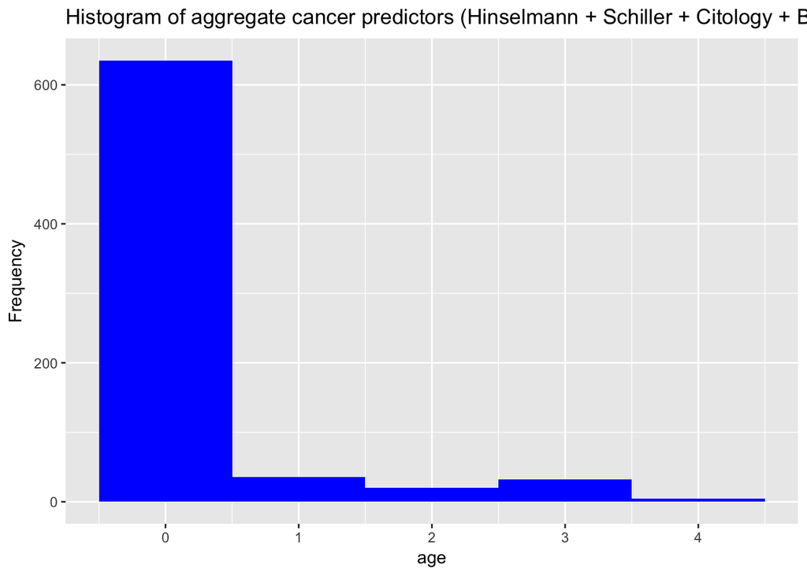

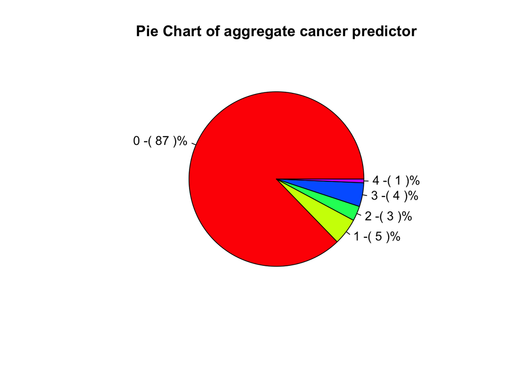

There are a great deal more values that equal 0 than any other value.

##### 0.4.0.0.2 Smoking

Captured in: `Smokes`, `Smokes..years.`, `Smokes..packs.year.`

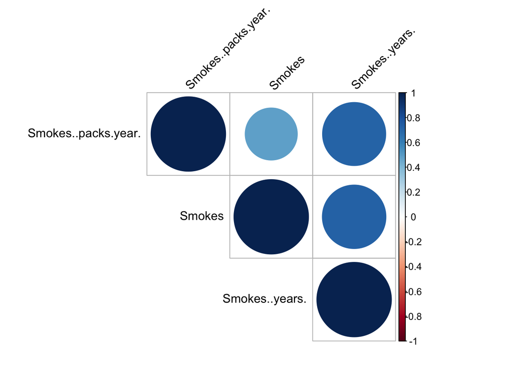

All these variables are highly correlated and could be combined.

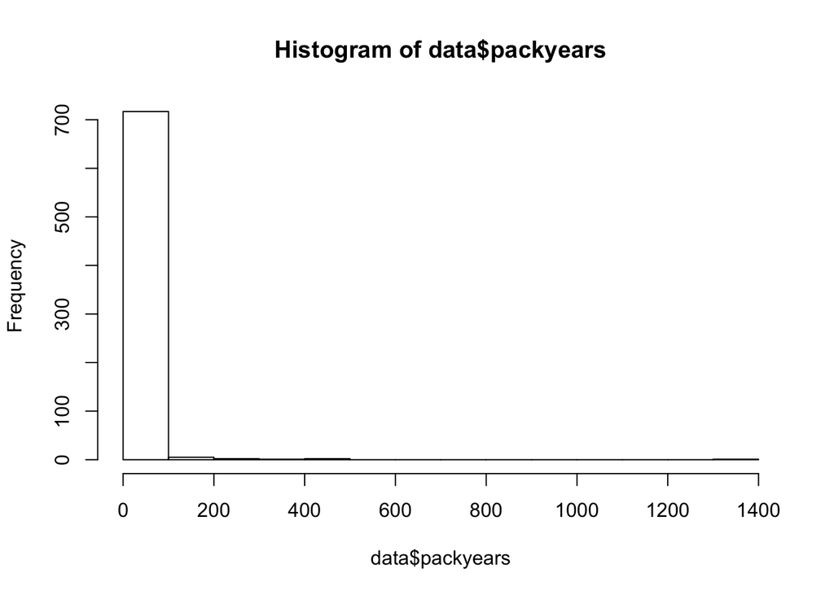

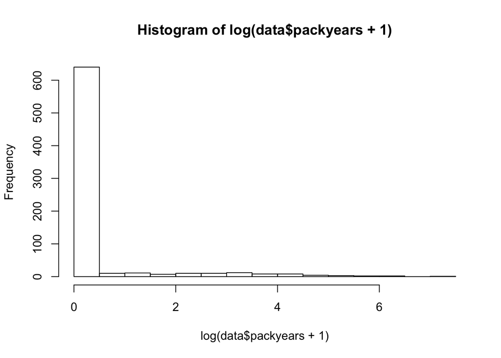

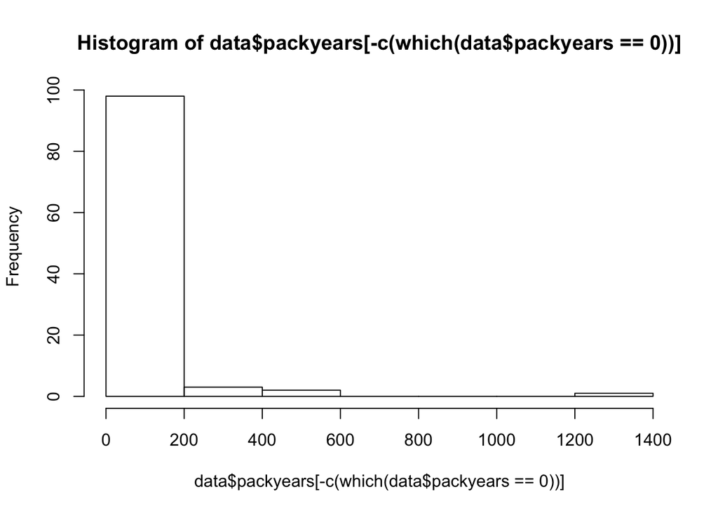

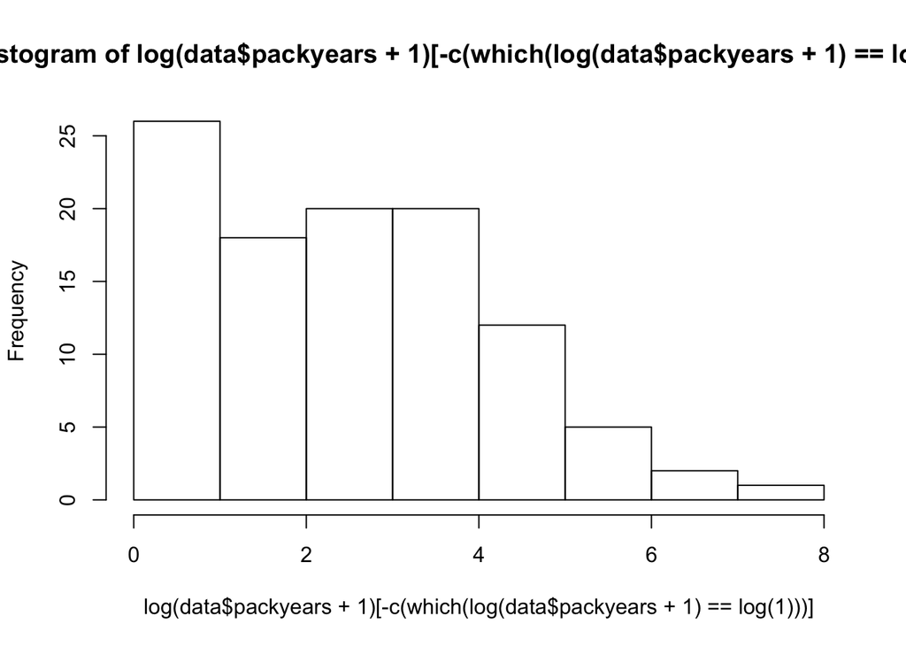

To address the interaction between the 3 smoking variables, a categorical variable `Smoker.status` was created. This was done first by a transformation to define “pack-years”: $Packyears = Smokes (yes=1, no=0) \times Smokes (years) \times Smokes (packs/year)$. Then, pack years was log transformed ($log(packyears+1)$) because, when excluding non-smokers ($log(packyears+1)=0$), the distribution for number of $log(packyears+1)$ looks more normal (as seen above). Finally, the mean was calculated for the group ($mean(log(packyears+1))=2.346$) and 0-2 were assigned as follows: + $Non-smoker(0)$: 0 log(packyears+1) + $Light-Medium smoker (1)$: Between 0 and 2.346 log(packyears+1) + $Heavy smoker (2)$: > 2.346 log(packyears+1)

The original smoking variables (`Smokes`, `Smokes..years.`, `Smokes..packs.year.`, `packyears`) were then removed fromt the dataset.

##### 0.4.0.0.3 `Age` -> `logAge`

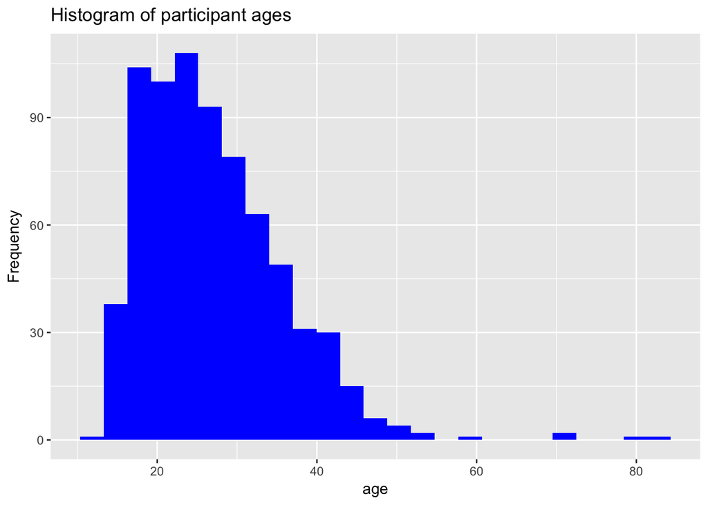

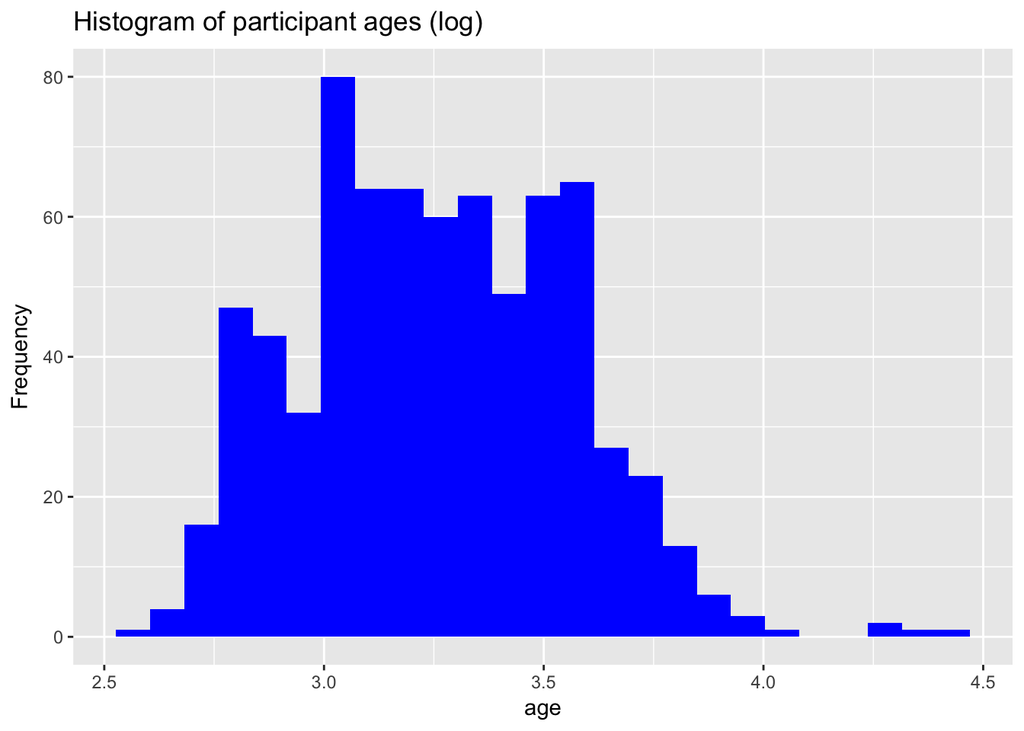

Taking the natural log of the age results in a more normal distribution.

##### 0.4.0.0.4 Sexual activity

Since the human papilloma virus (HPV) is the main risk factor for cervical cancer it makes sense to investigate variables that speak to this. From the data provided, sexual activity indicators are most salient, as HPV is contracted via sexual activity with an infected person.

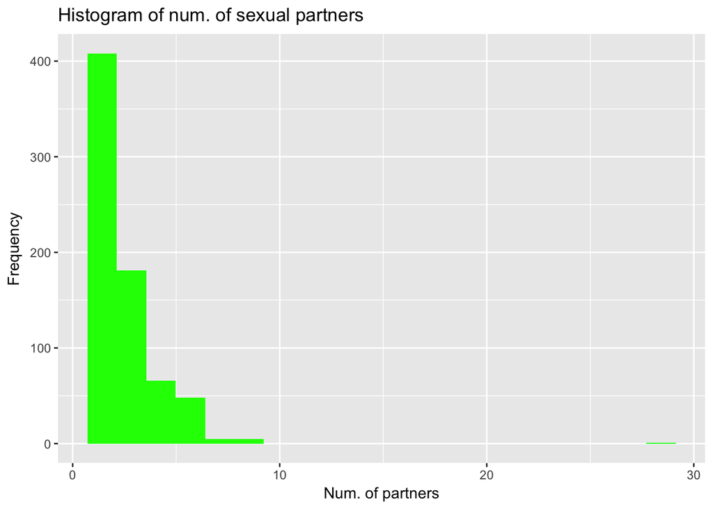

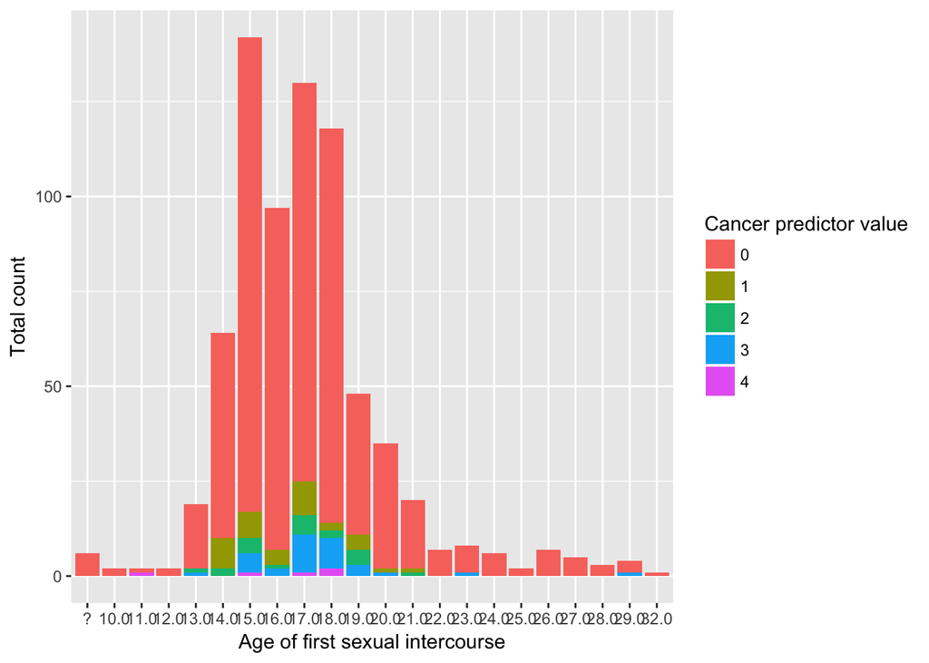

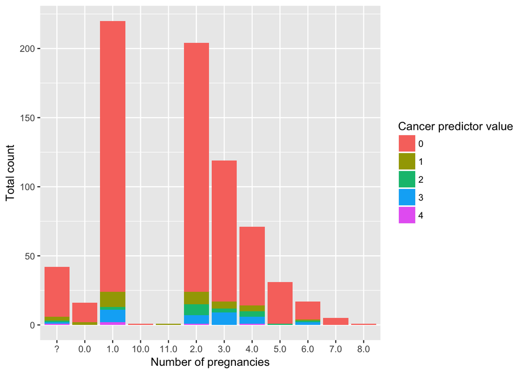

Exhibits normal distribution, and dependent variable slightly follows the data.

##### 0.4.0.0.5 HPV

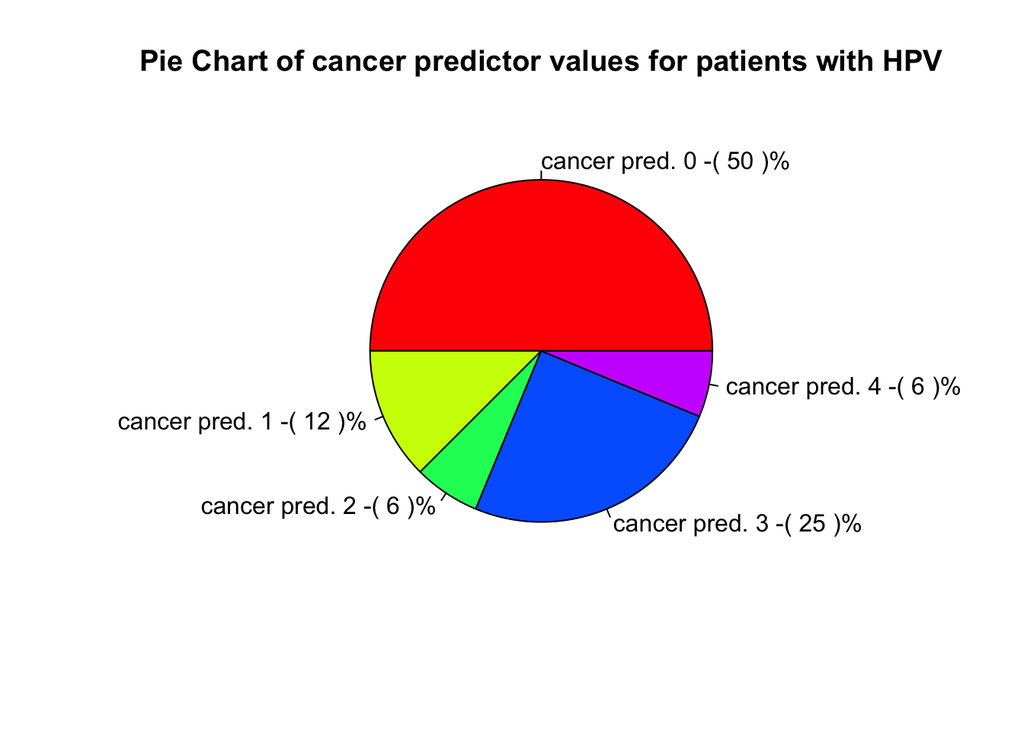

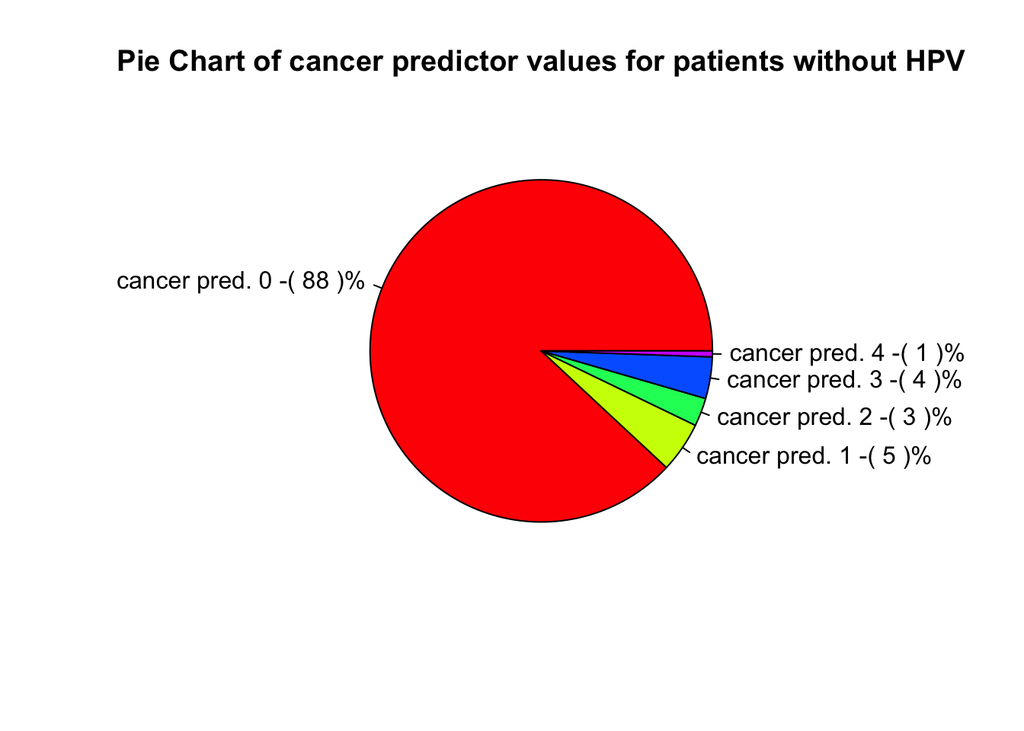

These pie graphs confirm our review of literature, showing that patients with HPV show a higher prevalence of cervical cancer markers.

### 0.4.1 Multicollinearity across variables

##### 0.4.1.0.1 Sexual history

Captured in: `Number.of.sexual.partners`, `First.sexual.intercourse`, `Num.of.pregnancies`

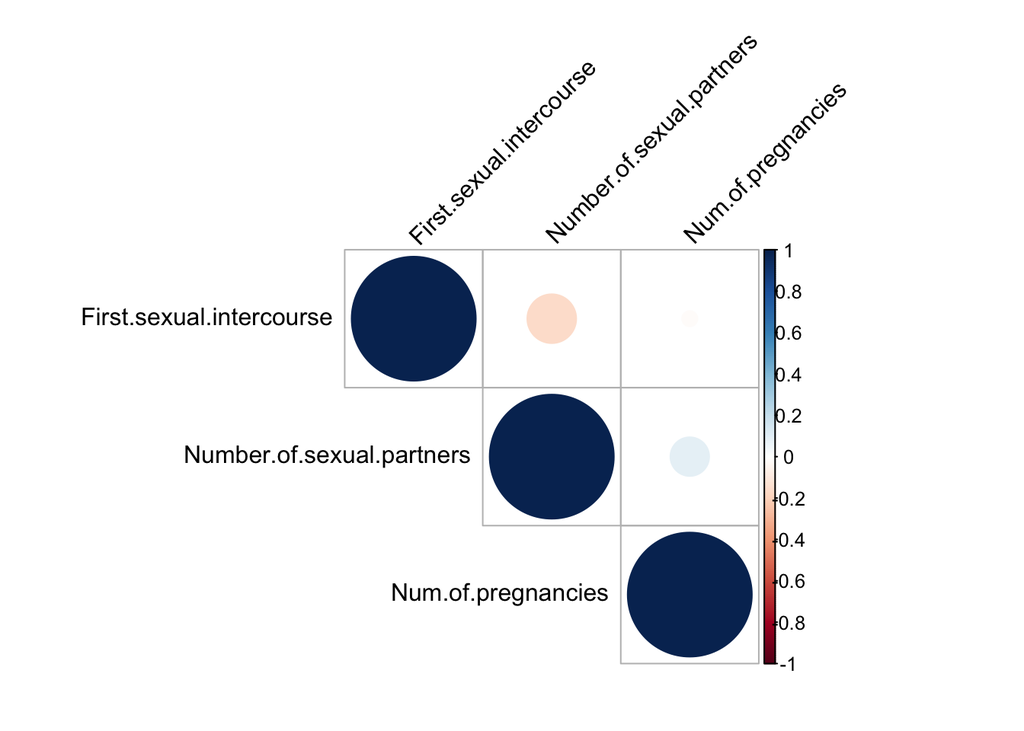

These variables are relatively uncorrelated, and thus can remain as they are.

##### 0.4.1.0.2 Contraception - Hormonal contraceptives & IUDs

Captured in: `Hormonal.Contraceptives`, `Hormonal.Contraceptives..years.`, `IUD`, `IUD..years.`

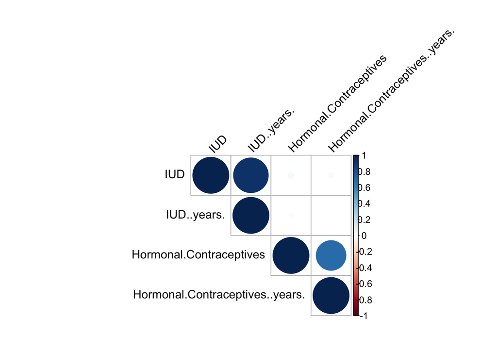

Results indicate that we should combine `IUD`/`IUD..years.`, and `Hormonal.Contraceptives`/`Hormonal.Contraceptives..years.`.

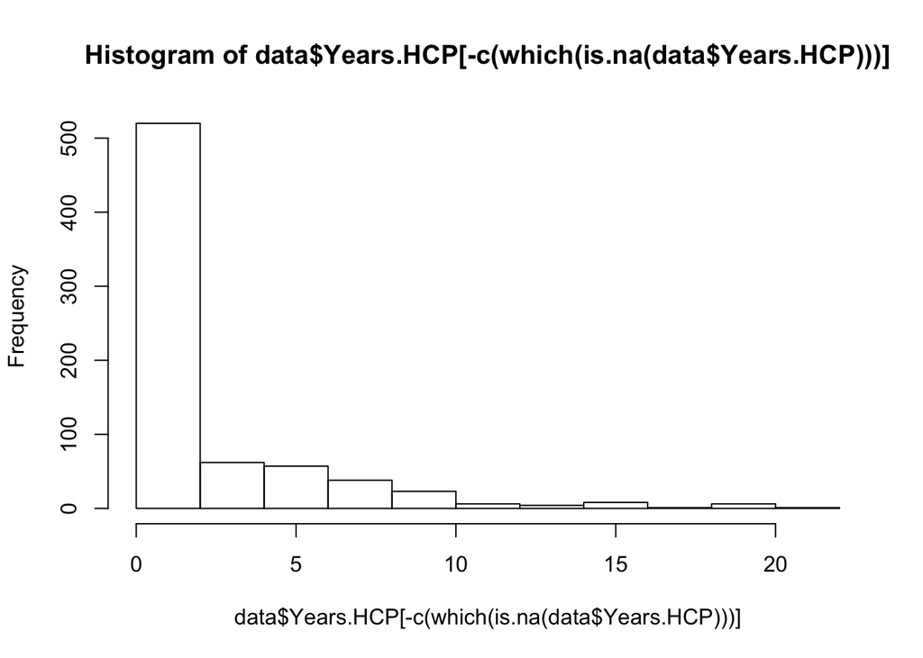

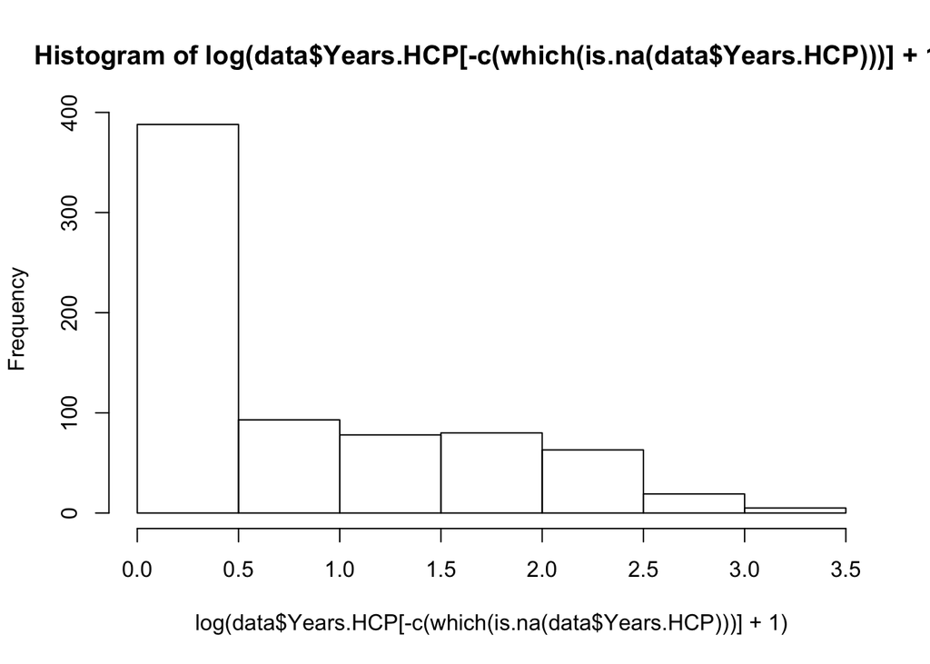

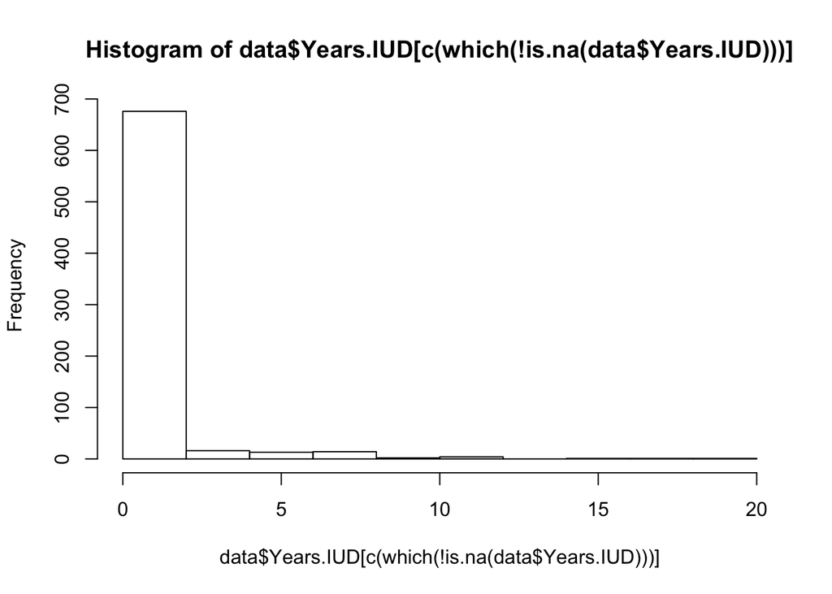

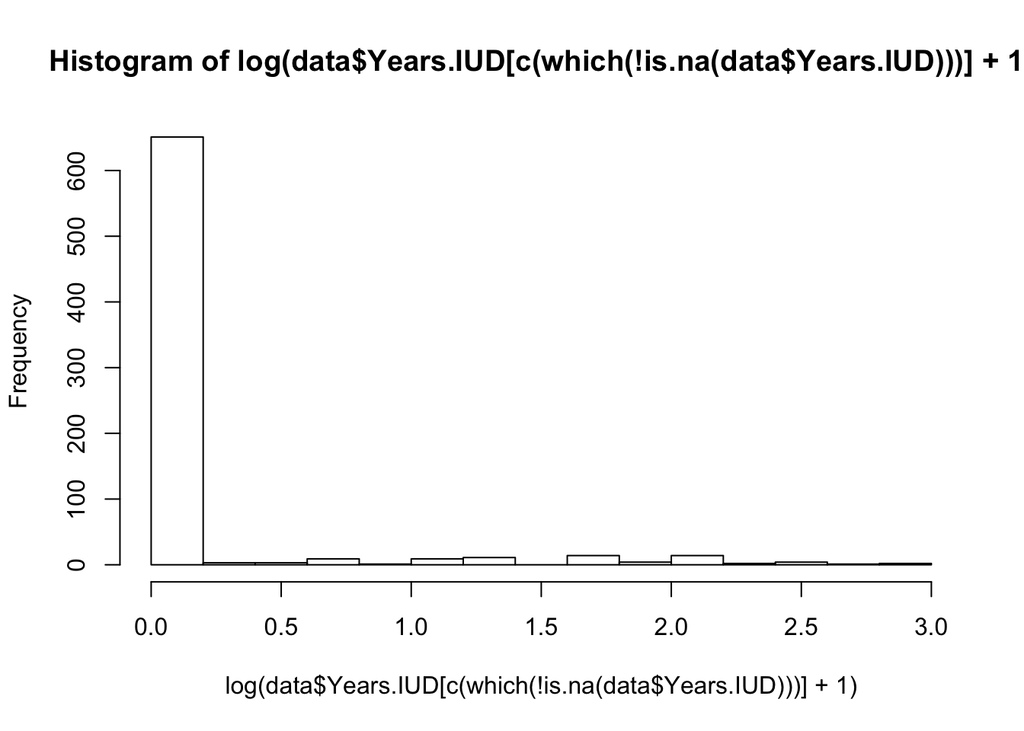

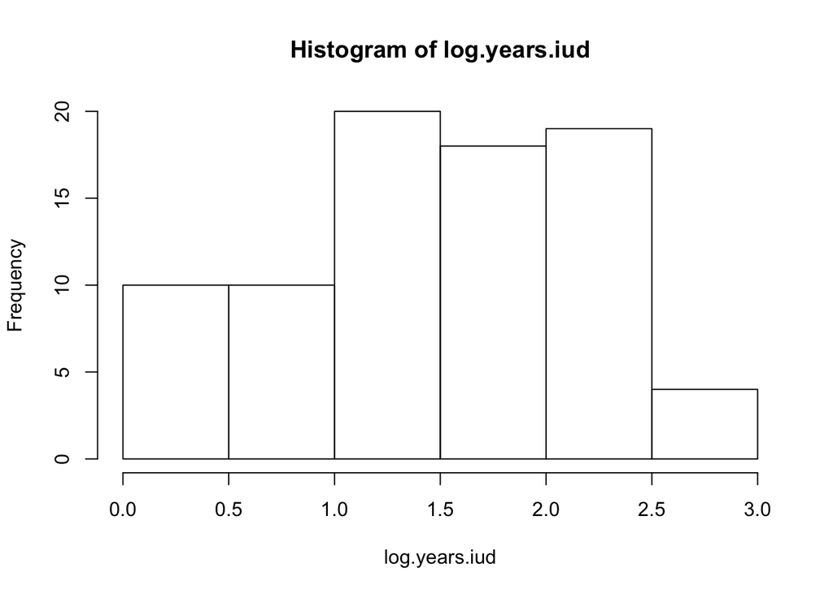

Similarly to `Smoker.status`, two new variables were created from the four original correlated variables. `log.Years.HCP` was created by multiplying $Years.HCP = Hormonal.Contraceptives(yes=1,no=0) \times Hormonal.Contraceptive.Years$ then taking the log transofrmation: $log.Years.HCP = log(Years.HCP + 1)$. The histograms before and after this process can be seen above. `log.Years.IUD` was created by multiplying $Years.IUD = IUD(yes=1,no=0) \times IUD.Years$, then taking the log transofrmation: $log.Years.IUD = log(Years.IUD + 1)$. As expected the histograms of the log transformed variables show a much better distribution than the originals.

The preliminary variables `Hormonal.Contraceptives`, `Hormonal.Contraceptives..years.`, `IUD`, `IUD..years.`, `Years.HCP`, and `Years.IUD` were then removed from the dataframe in lieu of the log values.

##### 0.4.1.0.3 STIs

Captured in: `STDs`, `STDs..number.`, `STDs.condylomatosis`, `STDs.vulvo.perineal.condylomatosis`, `STDs.syphilis`, `STDs..Number.of.diagnosis`

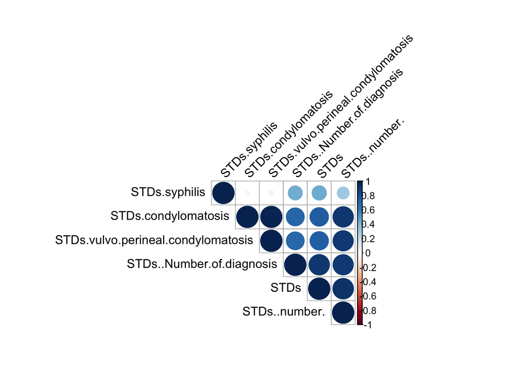

Unsurprsingly, there exists high correlation between many of these variables. To address this, we remove those with high correlation. As the figure shows, all variables except `STDs.syphilis` are highly correlated with `STDs.condylomatosis`. Consequently we leave those that are uncorrelated (`STDs.syphilis`, and `STDs.condylomatosis`) in the model, and remove the rest.

## 0.5 Model Description

### 0.5.1 Logistic Regression Overview

### 0.5.2 Logistic Regression Results

## 0.6 Alternative Methods

### 0.6.1 Overview of Boosting Method

### 0.6.2 Results of Boosting Method

### 0.6.3 Using PCA for interaction variables

## 0.7 Comparison of Methods

## 0.8 Validity of Results and Future Improvement

## 0.9 Conclusion

## 0.10 Appendix

### 0.10.1 Original variable descriptions

#### 0.10.1.1 Demographic

- `Age` - (int) Age
- `Smokes` - (bool) Smokes
- `Smokes..years.` - Smokes (years)
- `Smokes..packs.year.` - Smokes (packs/year)

#### 0.10.1.2 Contraception

- `Hormonal.Contraceptives` - (bool) Hormonal Contraceptives
- `Hormonal.Contraceptives..years.` - (int) Hormonal Contraceptives (years)
- `IUD` - (bool) IUD (Intrauterine device)
- `IUD..years.` - (int) IUD (years)

#### 0.10.1.3 Sexual activity history

- `Number.of.sexual.partners` - (int) Number of sexual partners
- `First.sexual.intercourse` - (int) First sexual intercourse (age)
- `Num.of.pregnancies` - (int) Num of pregnancies

#### 0.10.1.4 Sexual health history

- `STDs` - (bool) STDs
- `STDs..number.` - (int) STDs (number)
- `STDs.condylomatosis` - (bool) STDs:condylomatosis
- `STDs.cervical.condylomatosis` - (bool) STDs:cervical condylomatosis
- `STDs.vaginal.condylomatosis` - (bool) STDs:vaginal condylomatosis
- `STDs.vulvo.perineal.condylomatosis` - (bool) STDs:vulvo-perineal condylomatosis
- `STDs.syphilis` - (bool) STDs:syphilis
- `STDs.pelvic.inflammatory.disease` - (bool) STDs:pelvic inflammatory disease
- `STDs.genital.herpes` - (bool) STDs:genital herpes
- `STDs.molluscum.contagiosum` - (bool) STDs:molluscum contagiosum
- `STDs.AIDS` - (bool) STDs:AIDS
- `STDs.HIV` - (bool) STDs:HIV
- `STDs.Hepatitis.B` - (bool) STDs:Hepatitis B
- `STDs.HPV` - (bool) STDs:HPV
- `STDs..Number.of.diagnosis` - (int) STDs: Number of diagnosis
- `STDs..Time.since.first.diagnosis` - (int) STDs: Time since first diagnosis
- `STDs..Time.since.last.diagnosis` - (int) STDs: Time since last diagnosis

#### 0.10.1.5 Medical history

- `Dx.Cancer` - (bool) Dx:Cancer (person had previous cervical cancer diagnostic)
- `Dx.CIN` - (bool) Dx:CIN (person had previous diagnostic of Cervical intraepithelial neoplasia - the potentially premalignant transformation and abnormal growth (dysplasia) of squamous cells on the surface of the cervix)
- `Dx.HPV` - (bool) Dx:HPV
- `Dx` - (bool) Dx
- `Hinselmann` - (bool) Hinselmann: target variable
- `Schiller` - (bool) Schiller: target variable
- `Citology` - (bool) Cytology: target variable
- `Biopsy` - (bool) Biopsy: target variable